# feature_engineering_demo_p1_EDA

**特征工程**

有这么一句话在业界广泛流传：数据和特征决定了机器学习的上限，而模型和算法只是逼近这个上限而已。由此可见，特征工程在机器学习中占有相当重要的地位。在实际应用当中，可以说特征工程是机器学习成功的关键。

特征工程是数据分析中最耗时间和精力的一部分工作，它不像算法和模型那样是确定的步骤，更多是工程上的经验和权衡。因此没有统一的方法。这里只是对一些常用的方法做一个总结。

特征工程包含了 Data PreProcessing（数据预处理）、Feature Extraction（特征提取）、Feature Selection（特征选择）和 Feature construction（特征构造）等子问题。

- 数据集描述
  - 项目描述
  - 数据文件
  - 字段描述
- 探索性数据分析
  - 数据概览
  - 数据相关性
  - 目标变量分布

# 数据集描述

## 项目描述

本项目使用Kaggle上的 [家庭信用违约风险数据集 (Home Credit Default Risk)](https://www.kaggle.com/competitions/home-credit-default-risk/data) ，是一个标准的机器学习分类问题。其目标是使用历史贷款的信息，以及客户的社会经济和财务信息，预测客户是否会违约。

数据由Home Credit（捷信）提供，Home Credit致力于向无银行账户的人群提供信贷，是中东欧以及亚洲领先的消费金融提供商之一。在中东欧（CEE），俄罗斯，独联体国家（CIS）和亚洲各地服务于消费者。

Home Credit有三类产品，信用卡，POS（消费贷），现金贷，三类产品的英文分别是：Revolving loan (credit card)，Consumer installment loan (Point of sales loan – POS loan)，Installment cash loan。三类产品逻辑是这样的：

1. 首先提供POS，入门级产品，类似于消费贷。只能用于消费，金额有限，风险最小，客户提供的信息也最少。
2. 然后是credit card，在本次竞赛中称为revolving loan。循环授信，主要用于消费。
3. 最后才是cash loan，用户能得到现金，风险最大。

## 数据文件

数据集包括了8个不同的数据文件，大致可以分为三大类：

- application_{train|test}：包含每个客户社会经济信息和Home Credit贷款申请信息的主要文件。每行代表一个贷款申请，由SK_ID_CURR唯一标识。训练集30.75万数据，测试集4.87万数据。其中训练集中`TARGET=1`表示未偿还贷款。通过这两个文件，就能对这个任务做基本的数据分析和建模，也是本篇的主要内容。

用户在征信机构的历史征信记录可以用来作为风险评估的参考，但是征信数据往往不全，因为这些人本身就很少有银行记录。数据集中bureau.csv和 bureau_balance.csv 对应这部分数据。

- bureau：征信机构提供的客户之前在其他金融机构的贷款申请数据。一个用户（SK_ID_CURR）可以有多笔贷款申请数据（SK_ID_BUREAU）。总计171万数据。
- bureau_balance：征信机构统计的之前每笔贷款（SK_ID_BUREAU）的每月（MONTHS_BALANCE）的还款欠款记录。共有2729万条数据。

数据集中previous_application.csv, POS_CASH_balance.csv，credit_card_balance.csv，installments_payment.csv这部分数据是来自Home Credit产品的历史使用信息。信用卡在欧洲和美国很流行，但在以上这些国家并非如此。所以数据集中信用卡数据偏少。POS只能买东西，现金贷可以得到现金。三类产品都有申请和还款记录。

- previous_application：该表是客户在申请这次贷款之前的申请记录。一个用户（SK_ID_CURR）可以有多笔历史数据（SK_ID_PREV）。共计167万条。
- POS_CASH_balance：以前每月pos流水记录。由SK_ID_PREV和 months_balance唯一标识，共计1000万条数据。
- credit_card_balance：每月信用卡账单表。由MONTHS_BALANCE和SK_ID_PREV唯一标识，合计384万条数据。
- installments_payment：分期付款表。由 SK_ID_PREV, name_instalment_version, name_instalment_number 唯一标识，共计1360万条数据。

字段描述见附录。

# 探索性数据分析

Exploratory Data Analysis(EDA)

本篇主要通过application文件，做基本的数据分析和建模，也是本篇的主要内容。

## 数据概览

导入必要的包

```python
import numpy as np
import pandas as pd
import matplotlib.pyplot as plt
import seaborn as sns
import warnings

# Set global configuration.
warnings.filterwarnings('ignore')
sns.set_style('whitegrid')
pd.set_option('display.max_columns',None)
pd.set_option('display.max_rows',None)
pd.options.display.max_colwidth = 100

SEED = 42
```

```python
df = pd.read_csv('../datasets/Home-Credit-Default-Risk/application_train.csv')
# print(df.head())
```

```python
print('Training data shape: ', df.shape)
```

```
Training data shape:  (307511, 122)
```

```python
# `SK_ID_CURR` is the unique id of the row.
id_col = "SK_ID_CURR"
target = "TARGET"
df[id_col].nunique() == df.shape[0]
```

```
True
```

在遇到非常多的数据的时候，我们一般先会按照数据的类型分布下手，看看不同的数据类型各有多少

```python
# Number of each type of column
print(df.dtypes.value_counts())
```

```
float64    65
int64      41
object     16
Name: count, dtype: int64
```

```python
print("\nCategorical features:")
print(df.select_dtypes(["object"]).columns.tolist())
print("\nNumerical features:")
print(df.select_dtypes("number").columns.tolist())
```

```
Categorical features:
['NAME_CONTRACT_TYPE', 'CODE_GENDER', 'FLAG_OWN_CAR', 'FLAG_OWN_REALTY', 'NAME_TYPE_SUITE', 'NAME_INCOME_TYPE', 'NAME_EDUCATION_TYPE', 'NAME_FAMILY_STATUS', 'NAME_HOUSING_TYPE', 'OCCUPATION_TYPE', 'WEEKDAY_APPR_PROCESS_START', 'ORGANIZATION_TYPE', 'FONDKAPREMONT_MODE', 'HOUSETYPE_MODE', 'WALLSMATERI…

Numerical features:
['SK_ID_CURR', 'TARGET', 'CNT_CHILDREN', 'AMT_INCOME_TOTAL', 'AMT_CREDIT', 'AMT_ANNUITY', 'AMT_GOODS_PRICE', 'REGION_POPULATION_RELATIVE', 'DAYS_BIRTH', 'DAYS_EMPLOYED', 'DAYS_REGISTRATION', 'DAYS_ID_PUBLISH', 'OWN_CAR_AGE', 'FLAG_MOBIL', 'FLAG_EMP_PHONE', 'FLAG_WORK_PHONE', 'FLAG_CONT_MOBILE', 'FLA…
```

接下来看下数据集的统计信息

```python
print(df.describe())
```

```
          SK_ID_CURR         TARGET   CNT_CHILDREN  AMT_INCOME_TOTAL  \
count  307511.000000  307511.000000  307511.000000      3.075110e+05
mean   278180.518577       0.080729       0.417052      1.687979e+05
std    102790.175348       0.272419       0.722121      2.371231e+05
min    100002.000000       0.000000       0.000000      2.565000e+04
25%    189145.500000       0.000000       0.000000      1.125000e+05
50%    278202.000000       0.000000       0.000000      1.471500e+05
75%    367142.500000       0.000000       1.000000      2.025000e+05
max    456255.000000       1.000000      19.000000      1.170000e+08

         AMT_CREDIT    AMT_ANNUITY  AMT_GOODS_PRICE  \
count  3.075110e+05  307499.000000     3.072330e+05
mean   5.990260e+05   27108.573909     5.383962e+05
std    4.024908e+05   14493.737315     3.694465e+05
min    4.500000e+04    1615.500000     4.050000e+04
25%    2.700000e+05   16524.000000     2.385000e+05
50%    5.135310e+05   24903.000000     4.500000e+05
75%    8.086500e+05   34596.000000     6.795000e+05
max    4.050000e+06  258025.500000     4.050000e+06

       REGION_POPULATION_RELATIVE     DAYS_BIRTH  DAYS_EMPLOYED  \
count               307511.000000  307511.000000  307511.000000
mean                     0.020868  -16036.995067   63815.045904
std                      0.013831    4363.988632  141275.766519
min                      0.000290  -25229.000000  -17912.000000
25%                      0.010006  -19682.000000   -2760.000000
50%                      0.018850  -15750.000000   -1213.000000
75%                      0.028663  -12413.000000    -289.000000
max                      0.072508   -7489.000000  365243.000000

       DAYS_REGISTRATION  DAYS_ID_PUBLISH    OWN_CAR_AGE     FLAG_MOBIL  \
count      307511.000000    307511.000000  104582.000000  307511.000000
mean        -4986.120328     -2994.202373      12.061091       0.999997
std          3522.886321      1509.450419      11.944812       0.001803
min        -24672.000000     -7197.000000       0.000000       0.000000
25%         -7479.500000     -4299.000000       5.000000       1.000000
50%         -4504.000000     -3254.000000       9.000000       1.000000
75%         -2010.000000     -1720.000000      15.000000       1.000000
max             0.000000         0.000000      91.000000       1.000000

```

[output cut: 284 more lines]

```
min                     0.000000                   0.000000
25%                     0.000000                   0.000000
50%                     0.000000                   0.000000
75%                     0.000000                   0.000000
max                    27.000000                 261.000000

       AMT_REQ_CREDIT_BUREAU_YEAR
count               265992.000000
mean                     1.899974
std                      1.869295
min                      0.000000
25%                      0.000000
50%                      1.000000
75%                      3.000000
max                     25.000000
```

## 数据相关性

data Correlation

查看两两特征之间的相关程度，对特征的处理有指导意义。

```python
# The correlation matrix
corrmat = df.corr(numeric_only=True)

# Upper triangle of correlations
upper = corrmat.where(np.triu(np.ones(corrmat.shape), k=1).astype('bool'))

# Absolute value correlation
correlations = upper.unstack().dropna().sort_index()

correlations.abs().sort_values(ascending=False).head(20)
```

```
FLAG_EMP_PHONE                DAYS_EMPLOYED                  0.999755
YEARS_BUILD_MEDI              YEARS_BUILD_AVG                0.998495
OBS_60_CNT_SOCIAL_CIRCLE      OBS_30_CNT_SOCIAL_CIRCLE       0.998490
FLOORSMIN_MEDI                FLOORSMIN_AVG                  0.997241
FLOORSMAX_MEDI                FLOORSMAX_AVG                  0.997034
ENTRANCES_MEDI                ENTRANCES_AVG                  0.996886
ELEVATORS_MEDI                ELEVATORS_AVG                  0.996099
COMMONAREA_MEDI               COMMONAREA_AVG                 0.995978
LIVINGAREA_MEDI               LIVINGAREA_AVG                 0.995596
APARTMENTS_MEDI               APARTMENTS_AVG                 0.995081
BASEMENTAREA_MEDI             BASEMENTAREA_AVG               0.994317
LIVINGAPARTMENTS_MEDI         LIVINGAPARTMENTS_AVG           0.993825
YEARS_BEGINEXPLUATATION_MEDI  YEARS_BEGINEXPLUATATION_AVG    0.993825
LANDAREA_MEDI                 LANDAREA_AVG                   0.991610
NONLIVINGAPARTMENTS_MEDI      NONLIVINGAPARTMENTS_AVG        0.990768
NONLIVINGAREA_MEDI            NONLIVINGAREA_AVG              0.990444
YEARS_BUILD_MEDI              YEARS_BUILD_MODE               0.989463
YEARS_BUILD_MODE              YEARS_BUILD_AVG                0.989444
FLOORSMIN_MEDI                FLOORSMIN_MODE                 0.988406
FLOORSMAX_MEDI                FLOORSMAX_MODE                 0.988237
dtype: float64
```

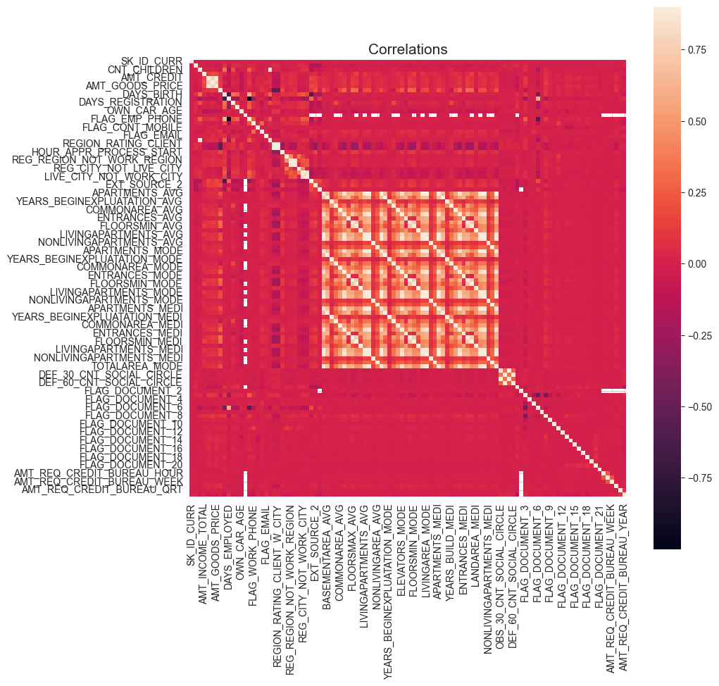

```python
fig, axs = plt.subplots(figsize=(10, 10))
sns.heatmap(corrmat, vmax=0.9, square=True)
axs.set_title('Correlations', size=15)
plt.show()
```

目标变量相关性

**Continuous Features**

```python
# Find correlations with the target and sort
print('Most Positive Correlations:\n', correlations["TARGET"].tail(15))
print('\nMost Negative Correlations:\n', correlations["TARGET"].head(15))
```

```
Most Positive Correlations:
 SK_ID_CURR   -0.002108
dtype: float64

Most Negative Correlations:
 SK_ID_CURR   -0.002108
dtype: float64
```

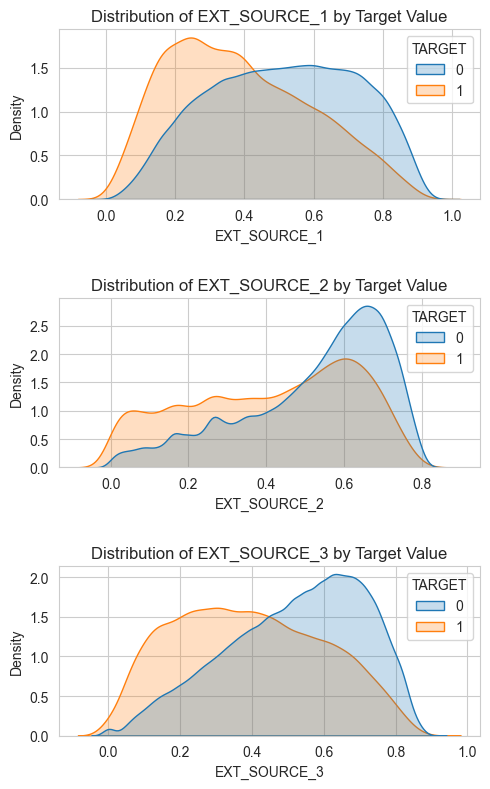

```python
# Extract the EXT_SOURCE variables and show correlations
cont_features = ['EXT_SOURCE_1', 'EXT_SOURCE_2', 'EXT_SOURCE_3']

fig = plt.figure(figsize=(5, 8))
plt.subplots_adjust(right=1.5)

for i, source in enumerate(cont_features):

    # Distribution of feature in dataset
    ax = fig.add_subplot(3, 1, i + 1)
    sns.kdeplot(x=source, data=df,
                hue=target,
                common_norm=False,
                fill=True,
                ax=ax)

    # Label the plots
    plt.title(f'Distribution of {source} by Target Value')
    plt.xlabel(f'{source}')
    plt.ylabel('Density')

plt.tight_layout(h_pad = 2.5)
```

```python
# Extract the EXT_SOURCE variables and show correlations
cont_features = ['EXT_SOURCE_1', 'EXT_SOURCE_2', 'EXT_SOURCE_3']

for source in cont_features:
    # Calculate the correlation coefficient between the variable and the target
    corr = df[target].corr(df[source])

    # Calculate medians for repaid vs not repaid
    avg_repaid = df.loc[df[target] == 0, source].median()
    avg_not_repaid = df.loc[df[target] == 1, source].median()

    # print out the correlation
    print('\nThe correlation between %s and the TARGET is %0.4f' % (source, corr))
    # Print out average values
    print('Median value for loan that was not repaid = %0.4f' % avg_not_repaid)
    print('Median value for loan that was repaid =     %0.4f' % avg_repaid)
```

```
The correlation between EXT_SOURCE_1 and the TARGET is -0.1553
Median value for loan that was not repaid = 0.3617
Median value for loan that was repaid =     0.5175

The correlation between EXT_SOURCE_2 and the TARGET is -0.1605
Median value for loan that was not repaid = 0.4404
Median value for loan that was repaid =     0.5739

The correlation between EXT_SOURCE_3 and the TARGET is -0.1789
Median value for loan that was not repaid = 0.3791
Median value for loan that was repaid =     0.5460
```

**Categorical Features**

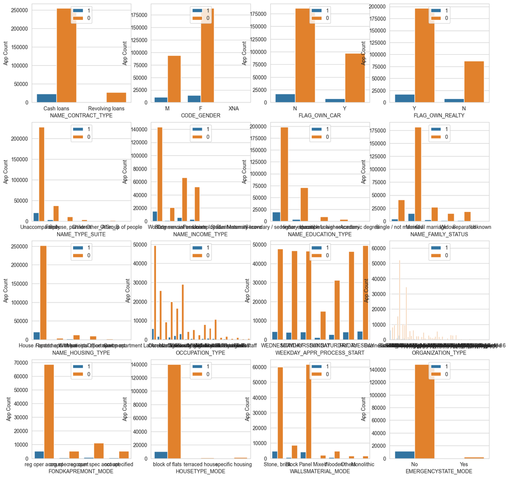

```python
cat_features = df.select_dtypes(["object"]).columns

fig = plt.figure(figsize=(16, 16))
for i, feature in enumerate(cat_features):
    ax = fig.add_subplot(4, 4, i+1)
    sns.countplot(x=feature, data=df,
                hue=df[target].map(lambda x:str(x)),
                fill=True,
                ax=ax)

    ax.set_xlabel(feature)
    ax.set_ylabel('App Count')
    ax.legend(loc='upper center')

plt.show()
```

## 目标变量分布

对于分类问题的目标变量，在sklearn中需要编码为数值型

| sklearn.preprocessing | 预处理 |
| --- | --- |
| LabelEncoder | 目标变量序数编码 |
| LabelBinarizer | 二分类目标数值化 |
| MultiLabelBinarizer | 多标签目标数值化 |

检查目标变量分布

```python
# `TARGET` is the target variable we are trying to predict (0 or 1):
# 1 = Not Repaid
# 0 = Repaid
target = 'TARGET'

print(f"percentage of default : {df[target].mean():.2%}")
print(df[target].value_counts())
```

```
percentage of default : 8.07%
TARGET
0    282686
1     24825
Name: count, dtype: int64
```

现实中，样本（类别）样本不平衡（class-imbalance）是一种常见的现象，一般地，做分类算法训练时，如果样本类别比例（Imbalance Ratio）（多数类vs少数类）严重不平衡时，分类算法将开始做出有利于多数类的预测。一般有以下几种方法：权重法、采样法、数据增强、损失函数、集成方法、评估指标。

| 方法 | 函数 | python包 |
| --- | --- | --- |
| SMOTE | SMOTE | imblearn.over_sampling |
| ADASYN | ADASYN | imblearn.over_sampling |
| Bagging算法 | BalancedBaggingClassifier | imblearn.ensemble |
| Boosting算法 | EasyEnsembleClassifier | imblearn.ensemble |
| 损失函数 | Focal Loss | self-define |

我们可以用[imbalance-learn](https://imbalanced-learn.org/stable/)这个Python库实现诸如重采样和模型集成等大多数方法。

对于回归任务，假设预测目标为客户的贷款额度`AMT_CREDIT`

```python
df['AMT_CREDIT'].describe()
```

```
count    3.075110e+05
mean     5.990260e+05
std      4.024908e+05
min      4.500000e+04
25%      2.700000e+05
50%      5.135310e+05
75%      8.086500e+05
max      4.050000e+06
Name: AMT_CREDIT, dtype: float64
```

我们画出AMT_CREDIT的分布图和QQ图。

> Quantile-Quantile图是一种常用的统计图形，用来比较两个数据集之间的分布。它是由标准正态分布的分位数为横坐标，样本值为纵坐标的散点图。如果QQ图上的点在一条直线附近，则说明数据近似于正态分布，且该直线的斜率为标准差，截距为均值。

```python
import matplotlib.pyplot as plt
import seaborn as sns
from scipy.stats import probplot, norm

def norm_comparison_plot(series):
    series = pd.Series(series)
    mu, sigma = norm.fit(series)
    kurt, skew = series.kurt(), series.skew()
    print(f"Kurtosis: {kurt:.2f}", f"Skewness: {skew:.2f}", sep='\t')

    fig = plt.figure(figsize=(10, 4))
    # Now plot the distribution
    ax1 = fig.add_subplot(121)
    ax1.set_title('Distribution')
    ax1.set_ylabel('Frequency')
    sns.distplot(series, fit=norm, ax=ax1)
    ax1.legend(['dist','kde','norm'],f'Normal dist. ($\mu=$ {mu:.2f} and $\sigma=$ {sigma:.2f} )', loc='best')
    # Get also the QQ-plot
    ax2 = fig.add_subplot(122)
    probplot(series, plot=plt)
```

```
Kurtosis: -0.29	Skewness: -0.34
```

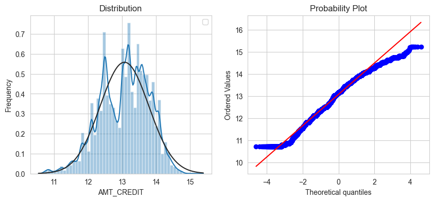

```python
norm_comparison_plot(np.log1p(df['AMT_CREDIT']))
plt.show()
```

可以看到经过对数变换后，基本符合正态分布了。

sklearn.compose 中的 TransformedTargetRegressor 是专门为回归任务设置的目标变换。对于简单的变换，TransformedTargetRegressor在拟合回归模型之前变换目标变量，预测时则通过逆变换映射回原始值。

```python
from sklearn.linear_model import LinearRegression
from sklearn.compose import TransformedTargetRegressor
from sklearn.preprocessing import FunctionTransformer

reg = TransformedTargetRegressor(regressor=LinearRegression(),
      transformer=FunctionTransformer(np.log1p))
```

# 附录：数据集字段描述

| Table | Row | 中文描述 |
| --- | --- | --- |
| application | SK_ID_CURR | 此次申请的ID |
| application | TARGET | 申请人本次申请的还款风险：1-风险较高；0-风险较低 |
| application | NAME_CONTRACT_TYPE | 贷款类型：cash(现金)还是revolving(周转金，一次申请，多次循环提取) |
| application | CODE_GENDER | 申请人性别 |
| application | FLAG_OWN_CAR | 申请人是否有车 |
| application | FLAG_OWN_REALTY | 申请人是否有房 |
| application | CNT_CHILDREN | 申请人子女个数 |
| application | AMT_INCOME_TOTAL | 申请人收入状况 |
| application | AMT_CREDIT | 此次申请的贷款金额 |
| application | AMT_ANNUITY | 贷款年金 |
| application | AMT_GOODS_PRICE | 如果是消费贷款，改字段表示商品的实际价格 |
| application | NAME_TYPE_SUITE | 申请人此次申请的陪同人员 |
| application | NAME_INCOME_TYPE | 申请人收入类型 |
| application | NAME_EDUCATION_TYPE | 申请人受教育程度 |
| application | NAME_FAMILY_STATUS | 申请人婚姻状况 |
| application | NAME_HOUSING_TYPE | 申请人居住状况（租房，已购房，和父母一起住等） |
| application | REGION_POPULATION_RELATIVE | 申请人居住地人口密度，已标准化 |
| application | DAYS_BIRTH | 申请人出生日（距离申请当日的天数，负值） |
| application | DAYS_EMPLOYED | 申请人当前工作的工作年限（距离申请当日的天数，负值） |
| application | DAYS_REGISTRATION | 申请人最近一次修改注册信息的时间（距离申请当日的天数，负值） |
| application | DAYS_ID_PUBLISH | 申请人最近一次修改申请贷款的身份证明文件的时间（距离申请当日的天数，负值） |
| application | OWN_CAR_AGE | 申请人车龄 |
| application | FLAG_MOBIL | 申请人是否提供个人电话（1-yes，0-no） |
| application | FLAG_EMP_PHONE | 申请人是否提供家庭电话（1-yes，0-no） |
| application | FLAG_WORK_PHONE | 申请人是否提供工作电话（1-yes，0-no） |
| application | FLAG_CONT_MOBILE | 申请人个人电话是否能拨通（1-yes，0-no） |
| application | FLAG_PHONE | 是否提供家庭电话 |
| application | FLAG_EMAIL | 申请人是否提供电子邮箱（1-yes，0-no） |
| application | OCCUPATION_TYPE | 申请人职务 |
| application | CNT_FAM_MEMBERS | 家庭成员数量 |

[output cut: 188 more lines]

[output not shown]

参考文献：

[Home Credit Default Risk - 1 之基础篇](https://zhuanlan.zhihu.com/p/104288764)  
[Home Credit Default Risk 之FeatureTools篇](https://zhuanlan.zhihu.com/p/104370111)  
[Feature Engineering for House Prices](https://www.kaggle.com/code/ryanholbrook/feature-engineering-for-house-prices)  
[Credit Fraud信用卡欺诈数据集，如何处理非平衡数据](https://blog.csdn.net/s09094031/article/details/90924284)  
[Predict Future Sales 预测未来销量, Kaggle 比赛，LB 0.89896 排名6%](https://blog.csdn.net/s09094031/article/details/90347191)  
[feature-engine](https://feature-engine.trainindata.com/en/latest/) 将特征工程中常用的方法进行了封装  
[分享关于人工智能的内容](https://blog.csdn.net/coco2d_x2014/category_8742518.html)

[特征工程系列：特征筛选的原理与实现（上）](https://cloud.tencent.com/developer/article/1469820) 7.23 [特征工程系列：特征筛选的原理与实现（下）](https://cloud.tencent.com/developer/article/1469822) 7.23 [特征工程系列：数据清洗](https://cloud.tencent.com/developer/article/1478305) 8.1 [特征工程系列：特征预处理（上）](https://cloud.tencent.com/developer/article/1483475) 8.8 [特征工程系列：特征预处理（下）](https://cloud.tencent.com/developer/article/1488245) 8.16 [特征工程系列：特征构造之概览篇](https://cloud.tencent.com/developer/article/1517948) 10.8 [特征工程系列：聚合特征构造以及转换特征构造](https://cloud.tencent.com/developer/article/1519994) 10.12 [特征工程系列：笛卡尔乘积特征构造以及遗传编程特征构造](https://cloud.tencent.com/developer/article/1521565) 10.15 [特征工程系列：GBDT特征构造以及聚类特征构造](https://cloud.tencent.com/developer/article/1530229) 10.30 [特征工程系列：时间特征构造以及时间序列特征构造](https://cloud.tencent.com/developer/article/1536537) 11.11 [特征工程系列：自动化特征构造](https://cloud.tencent.com/developer/article/1551874) 12.10 [特征工程系列：空间特征构造以及文本特征构造](https://cloud.tencent.com/developer/article/1551871) 12.10